# Python

# 批量爬取图片

```python
import urllib.request
import os
```

```python
def url_open(url):
    req=urllib.request.Request(url)
    req.add_header("User-Agent","Mozilla/5.0 (Windows NT 10.0; Win64; x64) AppleWebKit/537.36 (KHTML, like Gecko) Chrome/81.0.4044.92 Safari/537.36")
    response=urllib.request.urlopen(req)
    html = response.read()
    return html
```

```python
def get_page(url):
    #req=urllib.request.Request(url)
    #req.add_header("User-Agent","Mozilla/5.0 (Windows NT 10.0; Win64; x64) AppleWebKit/537.36 (KHTML, like Gecko) Chrome/81.0.4044.92 Safari/537.36")
    #response=urllib.request.urlopen(req)
    #html = response.read().decode("utf-8")
    html = url_open(url).decode("utf-8")
    a = html.find("current-comment-page")+23
    b=html.find("]",a)
    return html[a:b]

URL="http://jandan.net/ooxx/MjAyMDA0MTMtMjAw#comments"
get_page(URL)
```

```
'200'
```

```python
#url="http://jandan.net/ooxx/"

def find_imas(url):
    html = url_open(url).decode("utf-8")
    img_addrs = []
    a = html.find("img src=")

    while a!= -1:
        b = html.find(".jpg",a,a+255)
        if b!=-1:
            img_addrs.append(html[a+9:b+4])
        else:
            b=a+9
        a=html.find("img src=",b)

    return img_addrs

#find_imas(url)
```

```python
 def save_imgs(folder,img_addrs):
        for each in img_addrs:
            filename=each.split("/")[-1]
            with open(filename,"wb") as f:
                img = url_open('http:'+each)##通过查看each可知，没有http:， 故我们加上.得到的是单个图片的网址，所以不需要解码了，就像上面那个猫的例子
                f.write(img)
```

```python
#url="http://jandan.net/ooxx/"
#page_url=url+"MjAyMDA0MTItMTk"+str(1)+"#comments"
#img_addrs = find_imas(page_url)
#print(img_addrs)


#save_imgs("mm",img_addrs)
```

```python
def downlod_tu(folder="mei",pages=10):
    os.mkdir(folder)
    os.chdir(folder)
    url="http://jandan.net/ooxx/"
    page_num = int(get_page(url))

    for i in range(pages):
        page_num-=1
        page_url=url+"MjAyMDA0MTItMTk"+str(page_num)+"#comments"#先找出图片所在的网页
        img_addrs = find_imas(page_url)#找出上面所指的网页里面所有图片的地址，而该地址里面没有http:
        print(len(img_addrs))
        save_imgs(folder, img_addrs)

#if _name_=='_main_':
downlod_tu()
```

```
24
28
28
28
28
28
28
28
28
28
```

- 选择其中一张读取出来

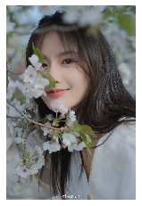

```python
import matplotlib.pyplot as plt # plt 用于显示图片
import matplotlib.image as mpimg # mpimg 用于读取图片
import numpy as np

cat = mpimg.imread('0076BSS5ly1gdr3a6bel2j30u0190net.jpg') # 读取和代码处于同一目录下的 lena.png
# 此时 cat 就已经是一个 np.array 了，可以对它进行任意处理
cat.shape

plt.imshow(cat) # 显示图片
plt.axis('off') # 不显示坐标轴
plt.show()
```

### 正则表达式

```python
import re
```

```python
re.search(r"Firsh", "I Love Firsh")
```

```
<re.Match object; span=(7, 12), match='Firsh'>
```

```python
re.search(r".", "I Love Firsh")#点好可以匹配任何字符，除了换行符
```

```
<re.Match object; span=(0, 1), match='I'>
```

```python
re.search(r"Firs.", "I Love Firsh")#因为点号可以匹配任何字符，所以这里的点号匹配h
```

```
<re.Match object; span=(7, 12), match='Firsh'>
```

- 因为点号是通配符，所以如果想找出字符串中的点号，需要用\转义，即

```python
re.search(r"\.","I Love baidu.com")
```

```
<re.Match object; span=(12, 13), match='.'>
```

```python
re.search(r"\d","I Love baidu123.com")#\d可以找出任何数字（第一个）
```

```
<re.Match object; span=(12, 13), match='1'>
```

```python
re.search(r"\d\d\d","I Love baidu123.com")
```

```
<re.Match object; span=(12, 15), match='123'>
```

```python
re.search(r"\d\d\d\.\d\d\d\.\d\d\d\.\d\d\d","192.168.111.123")#匹配一个IP地址
```

```
<re.Match object; span=(0, 15), match='192.168.111.123'>
```

- 字符类,即只要匹配到[]中任意一个就算匹配

```python
re.search(r"[aeiouAEIOU]","I love baidu.com")
```

```
<re.Match object; span=(0, 1), match='I'>
```

```python
re.search(r"[a-j]","I love baidu123.com.com")#a-j表示从a到j
```

```
<re.Match object; span=(5, 6), match='e'>
```

```python
re.search(r"[1-9]","I love baidu123.com.com")
```

```
<re.Match object; span=(12, 13), match='1'>
```

```python
re.search(r"ab{3}c","abbbc")
```

```
<re.Match object; span=(0, 5), match='abbbc'>
```

```python
re.search(r"ab{3,10}c","abbbbbbbbc")
```

```
<re.Match object; span=(0, 10), match='abbbbbbbbc'>
```

```python
re.search(r"[01]\d\d|2[0-4]\d|25[0-5]","188")
```

```
<re.Match object; span=(0, 3), match='188'>
```

```python
re.search(r"(([01]{0,1}\d{0,1}\d|2[0-4]\d|25[0-5])\.){3}([01]{0,1}\d{0,1}\d|2[0-4]\d|25[0-5])","192.178.1.1")#通用，可以匹配任意IP地址
```

```
<re.Match object; span=(0, 11), match='192.178.1.1'>
```

```python
re.search(r"\d\d\d\.\d\d\d\.\d\.\d","192.178.1.1")
```

```
<re.Match object; span=(0, 11), match='192.178.1.1'>
```

```python
re.search(r"firsh(C|D)","firshC")#(C|D)表示要么C要么D，|是或
```

```
<re.Match object; span=(0, 6), match='firshC'>
```

```python
re.search(r"firsh(C|D)","firshDE")
```

```
<re.Match object; span=(0, 6), match='firshD'>
```

```python
re.findall(r"[a-z]","Firsh.com")
```

```
['i', 'r', 's', 'h', 'c', 'o', 'm']
```

```python
re.findall(r"[^a-z]","Firsh.com")#^是取反的意思，即除了[]，匹配剩下的
```

```
['F', '.']
```

```python
result=re.search(r" (\w+) (\w+)","I love Python")#\w表示匹配任何单词赐福，+表示匹配其前面一次或者多次，()
```

```python
result
```

```
<re.Match object; span=(1, 13), match=' love Python'>
```

```python
result.group()
```

```
' love Python'
```

```python
result.group(1)#取出具体的
```

```
'love'
```

```python
result.group(2)
```

```
'Python'
```

```python
result.group(0)
```

```
' love Python'
```

```python
result.start()
```

```
1
```

```python
result.end()
```

```
13
```

### 利用正则表达式进行爬虫，简化关于字符串的命令

```python
import urllib.request
import re
```

```python
def url_open(url):
    req=urllib.request.Request(url)
    req.add_header("User-Agent","Mozilla/5.0 (Windows NT 10.0; Win64; x64) AppleWebKit/537.36 (KHTML, like Gecko) Chrome/81.0.4044.92 Safari/537.36")
    response=urllib.request.urlopen(req)
    html = response.read().decode("utf-8")
    return html
```

```python
def get_img(html):
    p=r'img src="([^"]+\.jpg)"'
    imglist=re.findall(p,html)#获取图片的地址如此简单

    #for each in imglist:
    #    print(each)
    for each in imglist:
        filename = each.split("/")[-1]
        urllib.request.urlretrieve(each,filename)
```

```python
url="http://www.duoziwang.com/head/haokan/"
#url_open(url)
get_img(url_open(url))
```

[figure not shown]

```python
import matplotlib.pyplot as plt # plt 用于显示图片
import matplotlib.image as mpimg # mpimg 用于读取图片
import numpy as np

cat = mpimg.imread('04042112981101.jpg') # 读取和代码处于同一目录下的 lena.png
# 此时 cat 就已经是一个 np.array 了，可以对它进行任意处理
cat.shape

plt.imshow(cat) # 显示图片
plt.axis('off') # 不显示坐标轴
plt.show()
```

## Scrapy

- Scrapy 是为了爬取网站数据，提取结构性数据而编写的框架。可以应用在包括数据挖掘，信息处理或存储历史数据等一系列的程序组。
- Scrapy 最初是为了页面抓取（更确切的说是 网络抓取）所设计的，也可以应用在获取API所返回的数据或者通用的爬虫。

#### 使用 Scrapy 抓取一个网站需要以下四个步骤

- 创建一个Scrapy项目
- 定义一个Itemr容器
- 编写爬虫
- 存储内容

```python
import scrapy
```

- 待续